# Language Fractionalization Project

## By Sahithi N Adari

### Definition

##### Ethnolinguistic Fractionalization (ELF): Refers to the probability that two randomly selected individuals from a population belonged to different groups

- High ELF means that the ethnicites and languages in a country are fairly heterogeneous (think India)
- Low ELF means that the ethnicites and languages in a country are fairly homogenous (think Japan)

### Background

##### By some estimates, 90% of the world's languages are going to die by the end of the 21st century. (Ken, 1992) Other estimations put this number closer to 50% (at a rate of losing a language every 3 months) (The Rosetta Project, 2013), but regardless of how much the end result is the same: we're losing the histories of people at a rapid rate.

##### Studies have shown that linguistic fractionalization benefits from the worst of globalization: “countries that have a high degree of fractionalization have less income redistribution, while capitalist countries that have a low degree of fractionalization have more income distribution.” (Sturm et. al., 2014)

### Original Question: What are the effects of globalization on linguistic fractionalization? And has the availability of the internet (as measured by usage) positively or negatively affected linguistic fractionalization within the 21st century?

### Updated Question: What are the effects of globalization on linguistic fractionalization? Are there globalization measures that are good predictors for linguistic fractionalization?

```python
#Imported the World Bank Infant Mortality Data
IMD = pd.read_excel(r'Datasets/IMR.xls')
IMD
```

|  | Data Source | World Development Indicators | Unnamed: 2 | Unnamed: 3 | Unnamed: 4 | Unnamed: 5 | Unnamed: 6 | Unnamed: 7 | Unnamed: 8 | Unnamed: 9 | ... | Unnamed: 55 | Unnamed: 56 | Unnamed: 57 | Unnamed: 58 | Unnamed: 59 | Unnamed: 60 | Unnamed: 61 | Unnamed: 62 | Unnamed: 63 | Unnamed: 64 |
| --- | --- | --- | --- | --- | --- | --- | --- | --- | --- | --- | --- | --- | --- | --- | --- | --- | --- | --- | --- | --- | --- |
| 0 | Last Updated Date | 2020-10-15 00:00:00 | NaN | NaN | NaN | NaN | NaN | NaN | NaN | NaN | ... | NaN | NaN | NaN | NaN | NaN | NaN | NaN | NaN | NaN | NaN |
| 1 | NaN | NaN | NaN | NaN | NaN | NaN | NaN | NaN | NaN | NaN | ... | NaN | NaN | NaN | NaN | NaN | NaN | NaN | NaN | NaN | NaN |
| 2 | Country Name | Country Code | Indicator Name | Indicator Code | 1960.0 | 1961.0 | 1962.0 | 1963.0 | 1964.0 | 1965.0 | ... | 2011.0 | 2012.0 | 2013.0 | 2014.0 | 2015.0 | 2016.0 | 2017.0 | 2018.0 | 2019.0 | 2020.0 |
| 3 | Aruba | ABW | Mortality rate, infant (per 1,000 live births) | SP.DYN.IMRT.IN | NaN | NaN | NaN | NaN | NaN | NaN | ... | NaN | NaN | NaN | NaN | NaN | NaN | NaN | NaN | NaN | NaN |
| 4 | Afghanistan | AFG | Mortality rate, infant (per 1,000 live births) | SP.DYN.IMRT.IN | NaN | NaN | 232.0 | 227.8 | 223.9 | 219.9 | ... | 61.7 | 59.5 | 57.2 | 55.2 | 53.2 | 51.3 | 49.6 | 48.0 | 46.5 | NaN |
| ... | ... | ... | ... | ... | ... | ... | ... | ... | ... | ... | ... | ... | ... | ... | ... | ... | ... | ... | ... | ... | ... |
| 262 | Kosovo | XKX | Mortality rate, infant (per 1,000 live births) | SP.DYN.IMRT.IN | NaN | NaN | NaN | NaN | NaN | NaN | ... | NaN | NaN | NaN | NaN | NaN | NaN | NaN | NaN | NaN | NaN |
| 263 | Yemen, Rep. | YEM | Mortality rate, infant (per 1,000 live births) | SP.DYN.IMRT.IN | NaN | NaN | 279.7 | 274.2 | 268.3 | 261.5 | ... | 43.1 | 43.0 | 43.0 | 43.0 | 43.4 | 43.3 | 43.3 | 43.6 | 43.6 | NaN |
| 264 | South Africa | ZAF | Mortality rate, infant (per 1,000 live births) | SP.DYN.IMRT.IN | NaN | NaN | NaN | NaN | NaN | NaN | ... | 30.5 | 29.8 | 29.2 | 29.0 | 28.5 | 28.2 | 28.2 | 27.8 | 27.5 | NaN |
| 265 | Zambia | ZMB | Mortality rate, infant (per 1,000 live births) | SP.DYN.IMRT.IN | 121.7 | 119.8 | 117.9 | 116.2 | 114.8 | 113.8 | ... | 51.0 | 49.9 | 48.7 | 47.5 | 46.7 | 45.8 | 44.1 | 43.4 | 42.4 | NaN |
| 266 | Zimbabwe | ZWE | Mortality rate, infant (per 1,000 live births) | SP.DYN.IMRT.IN | 92.8 | 90.5 | 88.2 | 85.8 | 83.2 | 80.7 | ... | 51.6 | 47.9 | 45.9 | 44.2 | 42.9 | 41.4 | 40.5 | 39.3 | 38.4 | NaN |

267 rows × 65 columns

```python
#Created a for loop that created a list of columns names from the 3rd row and change the datatype as appropriate
names = []
for x in IMD.iloc[2]:
    if isinstance(x, str):
        names.append(x)
    elif isinstance(x, float):
        y = x.astype(int)
        names.append(y)

#Changed the column names
IMD.columns = names

#Created a list of the column names I am interested in
notdrop = ['Country Name', 1961, 1985, 2001]

#Dropped all columns that were not in 'notdrop' list
for x in IMD.columns:
    if x not in notdrop:
        IMD = IMD.drop(columns = [x])

#Renamed a column
IMD.columns = ['Temp_Country', 'Infant_1961', 'Infant_1985', 'Infant_2001']

#Dropped rows
IMD = IMD.drop([0,1,2])
```

```python
#Created a dataframe of only the 1961 data from IMD
IMD_61 = IMD.drop(columns = ['Infant_1985', 'Infant_2001'])

#Inserted a row
IMD_61.insert(1, "Year", "1961")

#Renamed the columns
IMD_61.columns = ['Temp_Country', 'Year', 'Infant']

#Created a dataframe of only the 1985 data from IMD
IMD_85 = IMD.drop(columns = ['Infant_1961', 'Infant_2001'])

#Inserted a row
IMD_85.insert(1, "Year", "1985")

#Renamed the columns
IMD_85.columns = ['Temp_Country', 'Year', 'Infant']

#Created a dataframe of only the 2001 data from IMD
IMD_01 = IMD.drop(columns = ['Infant_1961', 'Infant_1985'])

#Inserted a row
IMD_01.insert(1, "Year", "2001")

#Renamed the columns
IMD_01.columns = ['Temp_Country', 'Year', 'Infant']

#Created a list of all the individual IMD dataframes
IMD_list = [IMD_61, IMD_85, IMD_01]
```

```python
#Concatted the 3 dataframes back into IMD
IMD = pd.concat(IMD_list)
IMD
```

|  | Temp_Country | Year | Infant |
| --- | --- | --- | --- |
| 3 | Aruba | 1961 | NaN |
| 4 | Afghanistan | 1961 | NaN |
| 5 | Angola | 1961 | NaN |
| 6 | Albania | 1961 | NaN |
| 7 | Andorra | 1961 | NaN |
| ... | ... | ... | ... |
| 262 | Kosovo | 2001 | NaN |
| 263 | Yemen, Rep. | 2001 | 65.7 |
| 264 | South Africa | 2001 | 46.6 |
| 265 | Zambia | 2001 | 85.0 |
| 266 | Zimbabwe | 2001 | 50.9 |

792 rows × 3 columns

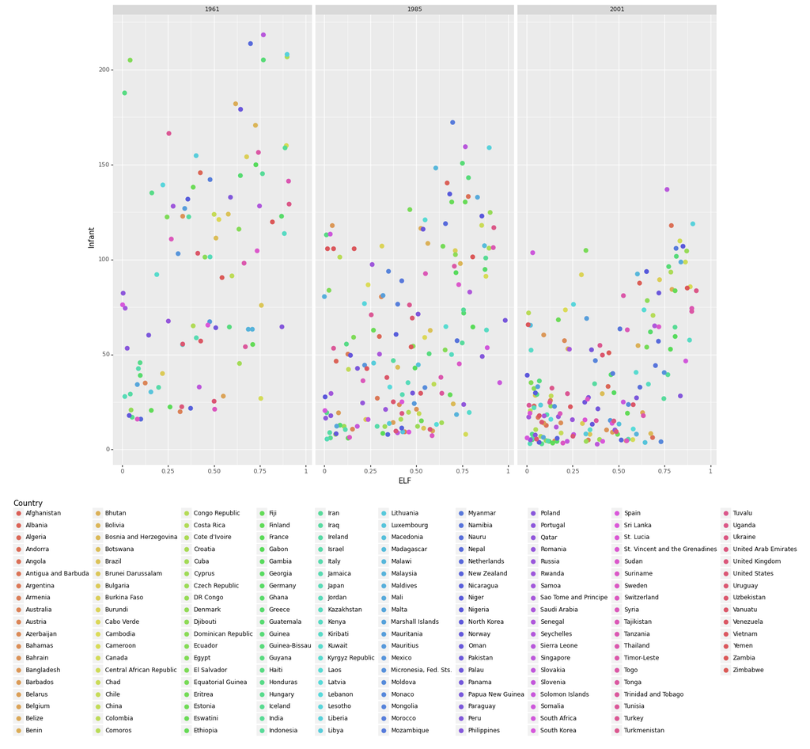

```python
(ggplot(temp, aes(x='ELF', y='Infant', color = "Country")) +
geom_point(size = 3) +
facet_wrap(['Year']) +
theme(legend_position = (0.5, -0.15), figure_size=(16, 12)))
```

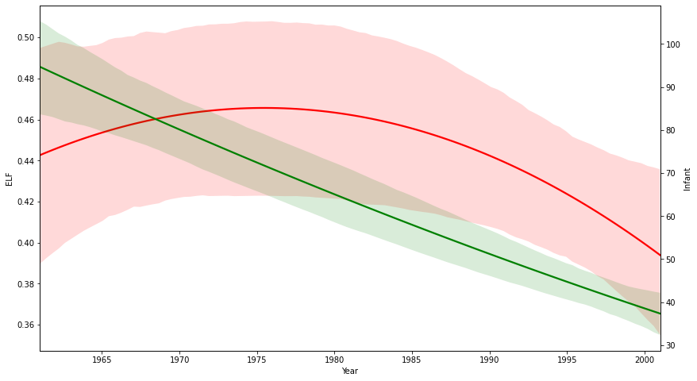

```python
fig, ax = plt.subplots(figsize=(14, 8))
sns.regplot(x="Year", y= "ELF", data = temp, color = 'red', order = 2, ax = ax, scatter = False)
ax2 = ax.twinx()
sns.regplot(x="Year", y= "Infant", data = temp, color = 'green', order = 2, ax = ax2, scatter = False)
```

```python
#Saved the absolute values of the correlation matrix
correlation = temp.corr().abs()

#Pivoted a level of the index labels
unstack_correlation = correlation.unstack()

#Sorted the correlations
compare = unstack_correlation.sort_values(kind="quicksort")

compare
```

```
Year    ELF       0.087516
ELF     Year      0.087516
        Infant    0.428920
Infant  ELF       0.428920
Year    Infant    0.467452
Infant  Year      0.467452
Year    Year      1.000000
ELF     ELF       1.000000
Infant  Infant    1.000000
dtype: float64
```

```python
y = temp['ELF'] # OUTCOME: the log selling price
X = temp[['Infant']] # PREDICTORS: simplified for our purposes

# (0) Split the data
train_X, test_X, train_y, test_y = train_test_split(X,y,test_size=.25,random_state=1988)

# (1) Set the folds index to ensure comparable samples
fold_generator = KFold(n_splits=5, shuffle=True,random_state=111)

# (2) Next specify the preprocessing steps
preprocess = ColumnTransformer(transformers=[('num', pp.MinMaxScaler(), ['Infant'])])


# (3) Next Let's create our model pipe (note for the model we leave none as a placeholder)
pipe = Pipeline(steps=[('pre_process', preprocess),
                       ('model',None)])


# (4) Specify the models and their repsective tuning parameters.
# Note the naming convention here to reference the model key
search_space = [
    # Linear Model
    {'model' : [LM()]},

    # KNN with K tuning param
    {'model' : [KNN()],
     'model__n_neighbors':[10,15,20,25,30]},

    # Decision Tree with the Max Depth Param
    {'model': [DTree()],
     'model__max_depth':[1,2,3,5]},

    # The Bagging decision tree model
    {'model': [Bag()]},

    # Random forest with the N Estimators tuning param
    {'model' : [RF()],
     'model__max_depth':[1,2,3],
     'model__n_estimators':[500,1000,1250]},
]


# (5) Put it all together in the grid search
search = GridSearchCV(pipe, search_space,
                      cv = fold_generator,
                      scoring='neg_mean_squared_error',
                      n_jobs=4)

# (6) Fit the model to the training data
search.fit(train_X,train_y)
```

```
GridSearchCV(cv=KFold(n_splits=5, random_state=111, shuffle=True),
             estimator=Pipeline(steps=[('pre_process',
                                        ColumnTransformer(transformers=[('num',
                                                                         MinMaxScaler(),
                                                                         ['Infant'])])),
                                       ('model', None)]),
             n_jobs=4,
             param_grid=[{'model': [LinearRegression()]},
                         {'model': [KNeighborsRegressor()],
                          'model__n_neighbors': [10, 15, 20, 25, 30]},
                         {'model': [DecisionTreeRegressor()],
                          'model__max_depth': [1, 2, 3, 5]},
                         {'model': [BaggingRegressor()]},
                         {'model': [RandomForestRegressor()],
                          'model__max_depth': [1, 2, 3],
                          'model__n_estimators': [500, 1000, 1250]}],
             scoring='neg_mean_squared_error')
```

```python
m.mean_squared_error(test_y,pred_y)
```

```
0.06863161887728654
```

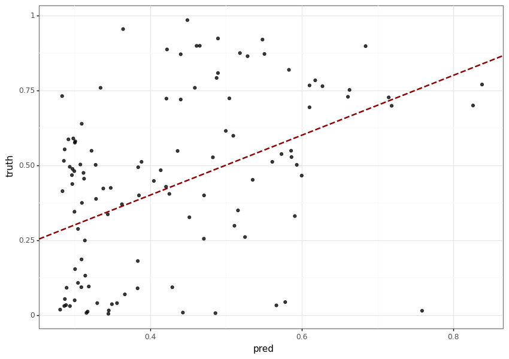

```python
(
    ggplot(pd.DataFrame(dict(pred=pred_y,truth=test_y)),
          aes(x='pred',y="truth")) +
    geom_point(alpha=.75) +
    geom_abline(linetype="dashed",color="darkred",size=1) +
    theme_bw() +
    theme(figure_size=(10,7))
)
```

### Learnings

- Dropping the Eurostat/internet useage dataset as a) it is survery based and b) doesn't have data for 2001
- ELF research is really sparce (only have data for the years 1961, 1985, 2001)
- Data clean up is taking a lot more time than the visualization or machine learning component

```python
#Importing 2003 fractionalization dataset & dropping 5 rows
heir = pd.read_excel(r'Datasets/BL2013_F_v2.2.xls')
heir.head(20)
```

|  | Unnamed: 0 | Unnamed: 1 | Unnamed: 2 | Unnamed: 3 | Unnamed: 4 | Unnamed: 5 | Unnamed: 6 | Unnamed: 7 | Unnamed: 8 | Unnamed: 9 | Unnamed: 10 | Unnamed: 11 | Unnamed: 12 | Unnamed: 13 | Unnamed: 14 | Unnamed: 15 | Unnamed: 16 |
| --- | --- | --- | --- | --- | --- | --- | --- | --- | --- | --- | --- | --- | --- | --- | --- | --- | --- |
| 0 | NaN | NaN | Educational Attainment for Female Population, ... | NaN | NaN | NaN | NaN | NaN | NaN | NaN | NaN | NaN | NaN | NaN | NaN | NaN | NaN |
| 1 | NaN | NaN | NaN | NaN | NaN | NaN | NaN | NaN | NaN | NaN | NaN | NaN | NaN | NaN | NaN | NaN | NaN |
| 2 | NaN | NaN | NaN | NaN | NaN | NaN | NaN | NaN | NaN | NaN | NaN | NaN | NaN | NaN | NaN | Barro R. & J.W. Lee | NaN |
| 3 | NaN | NaN | NaN | NaN | NaN | NaN | NaN | NaN | NaN | NaN | NaN | NaN | NaN | NaN | NaN | v. 2.2, June 2018 | NaN |
| 4 | NaN | NaN | NaN | NaN | NaN | NaN | NaN | NaN | NaN | NaN | NaN | NaN | NaN | NaN | NaN | NaN | NaN |
| 5 | 0 | 1 | 2 | 3.0 | 4 | 5 | 6 | 7 | 8 | 9 | 10 | 11 | 12 | 13 | 14 | 15 | 16 |
| 6 | Country | Year | Age Group | NaN | No Schooling | Highest level attained | NaN | NaN | NaN | NaN | NaN | Avg. Years of Total Schooling | Avg. Years of Primary Schooling | Avg. Years of Secondary Schooling | Avg. Years of Tertiary\n Schooling | Population\n(1000s) | Region |
| 7 | NaN | NaN | NaN | NaN | NaN | NaN | NaN | NaN | NaN | NaN | NaN | NaN | NaN | NaN | NaN | NaN | NaN |
| 8 | NaN | NaN | NaN | NaN | NaN | Primary | NaN | Secondary | NaN | Tertiary | NaN | NaN | NaN | NaN | NaN | NaN | NaN |
| 9 | NaN | NaN | NaN | NaN | NaN | Total | Completed | Total | Completed | Total | Completed | NaN | NaN | NaN | NaN | NaN | NaN |
| 10 | NaN | NaN | NaN | NaN | NaN | (% of population aged 15 and over) | NaN | NaN | NaN | NaN | NaN | NaN | NaN | NaN | NaN | NaN | NaN |
| 11 | NaN | NaN | NaN | NaN | NaN | NaN | NaN | NaN | NaN | NaN | NaN | NaN | NaN | NaN | NaN | NaN | NaN |
| 12 | NaN | NaN | NaN | NaN | NaN | NaN | NaN | NaN | NaN | NaN | NaN | NaN | NaN | NaN | NaN | NaN | NaN |
| 13 | Australia | 1950 | 15 | 19.0 | 1.71 | 29.95 | 16.16 | 58.51 | 29.34 | 9.83 | 1.35 | 8.54 | 5.48 | 2.83 | 0.22 | 273 | Advanced Economies |
| 14 | NaN | 1950 | 20 | 24.0 | 0.7 | 33 | 15.83 | 55.2 | 34.05 | 11.1 | 3.66 | 8.63 | 5.44 | 2.89 | 0.3 | 313 | Advanced Economies |
| 15 | NaN | 1950 | 25 | 29.0 | 0.7 | 33 | 18.95 | 55.2 | 29.96 | 11.1 | 5.92 | 8.69 | 5.54 | 2.81 | 0.34 | 333 | Advanced Economies |
| 16 | NaN | 1950 | 30 | 34.0 | 0.8 | 41.9 | 26.46 | 47.6 | 23.12 | 9.7 | 5.27 | 8.16 | 5.49 | 2.38 | 0.3 | 304 | Advanced Economies |
| 17 | NaN | 1950 | 35 | 39.0 | 0.8 | 41.9 | 24.5 | 47.6 | 21.86 | 9.7 | 5.18 | 8.08 | 5.43 | 2.35 | 0.3 | 307 | Advanced Economies |
| 18 | NaN | 1950 | 40 | 44.0 | 1.2 | 49 | 28.65 | 40.7 | 17.68 | 9.1 | 4.83 | 7.63 | 5.32 | 2.03 | 0.28 | 267 | Advanced Economies |
| 19 | NaN | 1950 | 45 | 49.0 | 1.2 | 49 | 28.65 | 40.7 | 16.87 | 9.1 | 4.72 | 7.61 | 5.32 | 2.01 | 0.28 | 236 | Advanced Economies |